# Assignment: Naive Bayes and Logistic Classifiers

Karan Pillay

January 29, 2020

# Problem 1

**Q1. Use derivative of f(x) to find the value of x that minimizes this function.** Find the value of x that minimizes this function: $f(x) = x^2+6x$ set f’(x)=0 so we can find the points:
$$f'(x) = 2x+6=0 -----> x = -3$$
Now plug in x vales from the first step into $f(x)$ to generate y coordinate
$$f(-3) = (-3)^2+6(-3) = -9$$
An x = -3 will minimize the $f(x)$ function. The minimum point is at (-3,-9)

**Q2. Use gradient descent to find the value of x that minimizes this function. Compare your answer with the previous part.**

```r
library(grid)
library(dplyr)
library(scales)
```

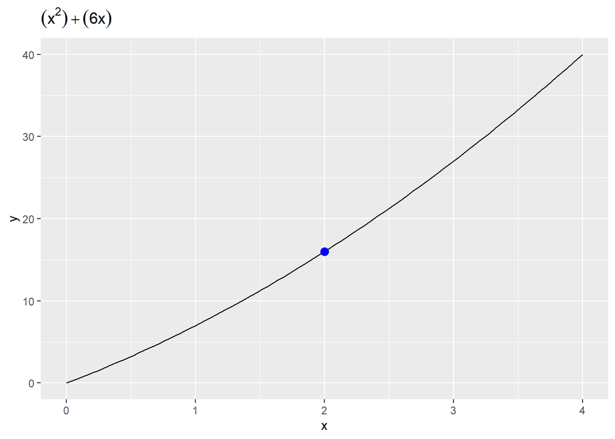

```r
library(ggplot2)
Formula <- function(x) (x^2) + (6*x)

ggplot( data.frame( x = c(0, 4) ), aes(x) ) +
stat_function(fun = Formula) +
geom_point( data = data.frame( x = 2, y = Formula(2) ), aes(x, y),
            color = "blue", size = 3 ) +
ggtitle( expression( (x^2) + (6*x) ) )
```

```r
Derivative <- function(x) 2 * (x+3)

# define the alpha value (learning rate)
learning_rate <- .6

# define the initial value
x <- .1

( iteration <- data.frame( x = x, value = Formula(x) ) )
```

```
##     x value
## 1 0.1  0.61
```

```r
# apply the formula of gradient descent
x <- x- learning_rate * Derivative(x)

# output
rbind( iteration, c( x, Formula(x) ) )
```

```
##       x   value
## 1  0.10  0.6100
## 2 -3.62 -8.6156
```

```r
x_new <- .1
x_old <- 0

# define the alpha value (learning rate)
learning_rate <- .6

# define the epilson value, maximum iteration allowed
epsilon <- .05
step <- 1
iteration <- 10

# records the x and y value for visualization ; add the inital guess
xtrace <- list() ; ytrace <- list()
xtrace[[1]] <- x_new ; ytrace[[1]] <- Formula(x_new)
cbind( xtrace, ytrace )
```

```
##      xtrace ytrace
## [1,] 0.1    0.61
```

```r
while( abs(x_new - x_old) > epsilon & step <= iteration )
{
    # update iteration count
    step <- step + 1

    # gradient descent
    x_old <- x_new
    x_new <- x_old - learning_rate * Derivative(x_old)

    # record keeping
    xtrace[[step]] <- x_new
    ytrace[[step]] <- Formula(x_new)
}

# create the data points' dataframe
record <- data.frame( x = do.call(rbind, xtrace), y = do.call(rbind, ytrace) )
record
```

```
##          x         y
## 1  0.10000  0.610000
## 2 -3.62000 -8.615600
## 3 -2.87600 -8.984624
## 4 -3.02480 -8.999385
## 5 -2.99504 -8.999975
```

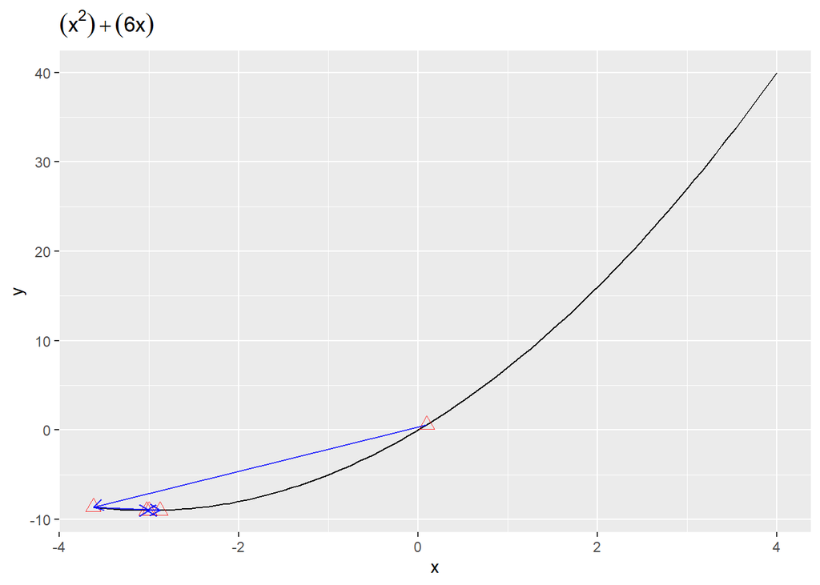

```r
# create the segment between each points (gradient steps)
segment <- data.frame( x = double(), y = double(), xend = double(), yend = double() )
for( i in 1:( nrow(record)-1 ) ) {
    segment[ i, ] <- cbind( record[i, ], record[i + 1, ] )
}

# visualize the gradient descent's value
ggplot( data.frame( x = c(0, 4) ), aes(x) ) +
stat_function(fun = Formula) +
ggtitle( expression( (x^2) + (6*x) ) ) +
geom_point( data = record, aes(x, y), color = "red", size = 3, alpha = .8, shape = 2 ) +
geom_segment( data = segment , aes(x = x, y = y, xend = xend, yend = yend),
              color = "blue", alpha = .8, arrow = arrow( length = unit(0.25, "cm") ) )
```

# Problem 2

```r
d <- read.csv(file="ORing.csv", header=TRUE, sep=",")

d.bkup <- d
head(d)
```

```
##   Temp Failure
## 1   53       1
## 2   56       1
## 3   57       1
## 4   63       0
## 5   66       0
## 6   67       0
```

```r
Mean <- mean(d$Temp)
print(Mean)
```

```
## [1] 69.91667
```

```r
SD <- sd(d$Temp, na.rm = FALSE)
print(SD)
```

```
## [1] 7.377502
```

**Q1. Normalize the launch temperature using the expression x−µ/σ.**

```r
normalize <- function(x) {
return ((x - mean(x)) / sd(x))
}
nor_temp <-normalize(d$Temp)
head(nor_temp)
```

```
## [1] -2.2930074 -1.8863657 -1.7508184 -0.9375350 -0.5308933 -0.3953461
```

```r
new_data <- data.frame(Temp = nor_temp, Failure = d$Failure, stringsAsFactors = FALSE)
head(new_data)
```

```
##         Temp Failure
## 1 -2.2930074       1
## 2 -1.8863657       1
## 3 -1.7508184       1
## 4 -0.9375350       0
## 5 -0.5308933       0
## 6 -0.3953461       0
```

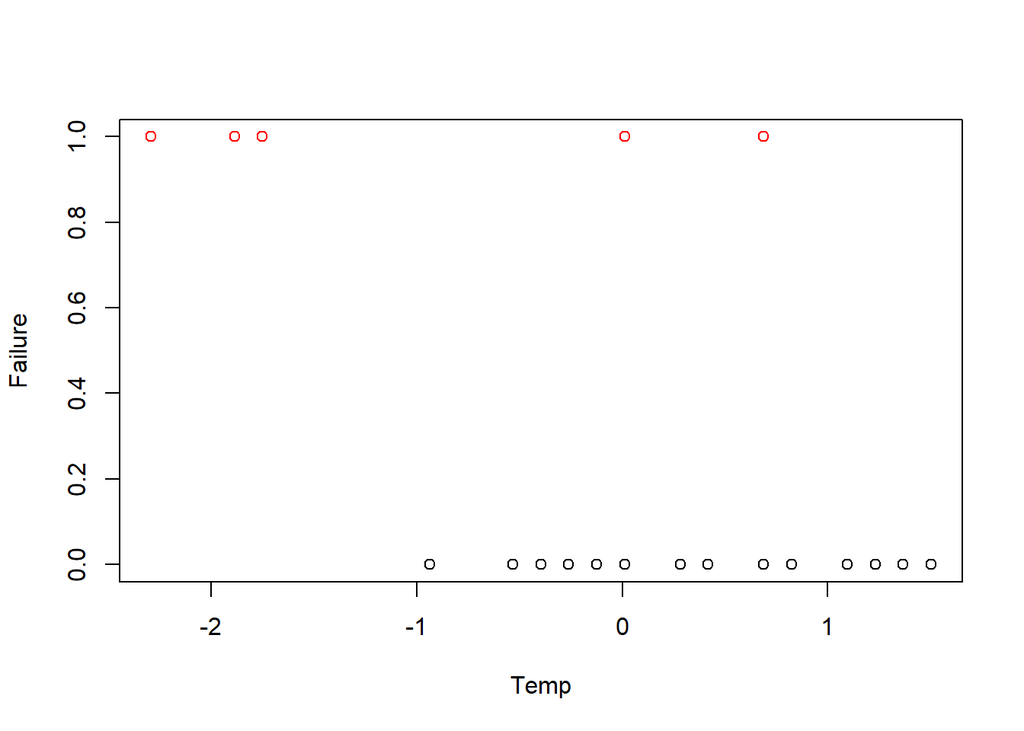

```r
plot(new_data$Temp, new_data$Failure, col=as.factor(d$Failure),ylab="Failure", xlab =  "Temp")
```

**Q2. Create a logistic regression model using the gradient decent technique to predict the probability of O-ring failure based on the launch temperature.Provide the equation for your model.**

```r
library(ggplot2)
library(dplyr)
#sigmoid function, inverse of logit
sigmoid <- function(z){1/(1+exp(-z))}

#cost function
cost <- function(theta, X, y){
  m <- length(y) # number of training examples

  h <- sigmoid(X%*%theta)
  J <- (t(-y)%*%log(h)-t(1-y)%*%log(1-h))/m
  J
}

#gradient function
grad <- function(theta, X, y){
  m <- length(y)

  h <- sigmoid(X%*%theta)
  grad <- (t(X)%*%(h - y))/m
  grad
}
```

```r
logisticReg <- function(X, y){
  #remove NA rows
  temp <- na.omit(cbind(y, X))
  #convert to matrix
  X <- as.matrix(new_data[, 1])
  y <- as.matrix(new_data[, -1])
  #initialize theta
  theta <- matrix(rep(0, ncol(X)), nrow = ncol(X))
  #use the optim function to perform gradient descent
  costOpti <- optim(matrix(rep(0,1), nrow = 1), cost, grad, X=X, y=y)
  #return coefficients
  return(costOpti$par)
}
```

```r
data.X <- new_data['Temp']
data.y <- new_data['Failure']

mod <- logisticReg(data.X, data.y)
mod
```

```
##           [,1]
## [1,] -1.142969
```

```r
#Finding the predictions of the model
mod1 <- glm(as.factor(Failure) ~ Temp,
            family=binomial(link = "logit"), data=new_data)

summary(mod1)
```

```
##
## Call:
## glm(formula = as.factor(Failure) ~ Temp, family = binomial(link = "logit"),
##     data = new_data)
##
## Deviance Residuals:
##     Min       1Q   Median       3Q      Max
## -1.2125  -0.8253  -0.4706   0.5907   2.0512
##
## Coefficients:
##             Estimate Std. Error z value Pr(>|z|)
## (Intercept)  -1.1028     0.5400  -2.042   0.0411 *
## Temp         -1.2639     0.6156  -2.053   0.0400 *
## ---
## Signif. codes:  0 '***' 0.001 '**' 0.01 '*' 0.05 '.' 0.1 ' ' 1
##
## (Dispersion parameter for binomial family taken to be 1)
##
##     Null deviance: 28.975  on 23  degrees of freedom
## Residual deviance: 23.030  on 22  degrees of freedom
## AIC: 27.03
##
## Number of Fisher Scoring iterations: 4
```

```r
res <- predict(mod1,new_data, type = "response")
head(res)
```

```
##         1         2         3         4         5         6
## 0.8575835 0.7826882 0.7521441 0.5205279 0.3936957 0.3536292
```

```r
#Finding the confusion matrix
confmatrix <- table(Actual_Value = d$Failure, Predicted_Value = res>0.5 )
confmatrix
```

```
##             Predicted_Value
## Actual_Value FALSE TRUE
##            0    16    1
##            1     4    3
```

```r
#Finding the accuracy of the model
Accuracy <-(confmatrix[[1,1]] + confmatrix[[2,2]]) / sum(confmatrix)
print(Accuracy)
```

```
## [1] 0.7916667
```

Equation for the model

h(x) =$\frac {e^{-1.1028 -1.2639*Temp}}{1 + e^{-1.1028 -1.2639*Temp}}$=$\frac {1}{1 + e^{1.1028 +1.2639*Temp}}$

**Q3. Provide a plot of the original data along with your logistic model.**

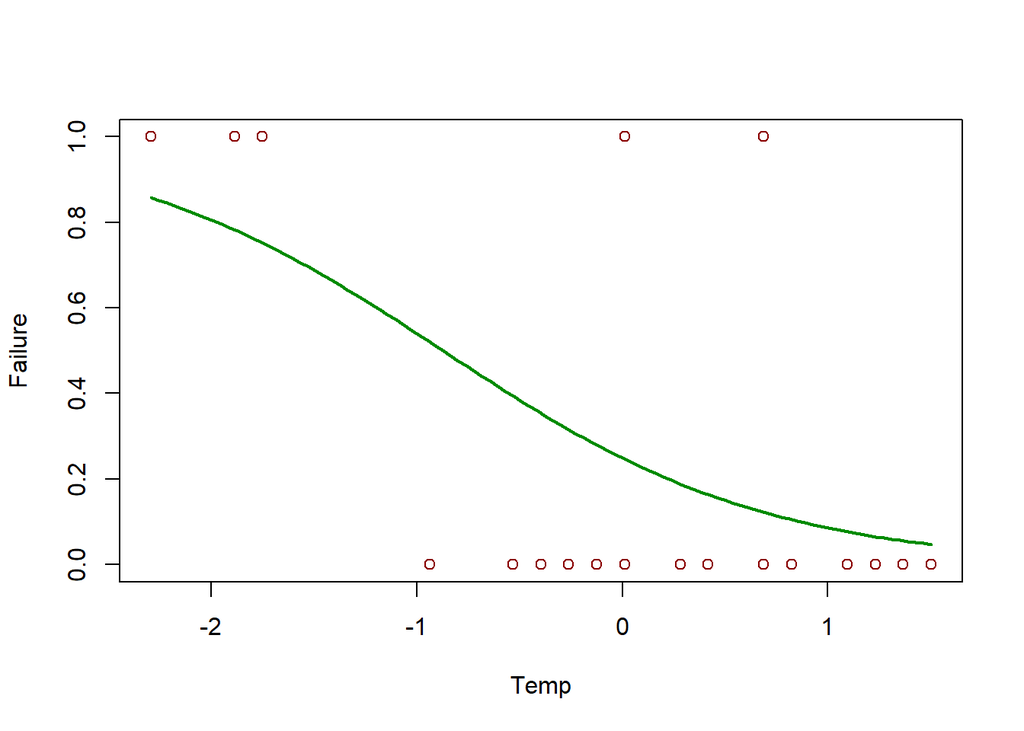

```r
#ploting the model
newdat <- data.frame(Temp=seq(min(new_data$Temp), max(new_data$Temp),len=100))
newdat$Failure = predict(mod1, newdata=newdat, type="response")
plot(Failure~Temp, data=new_data, col="red4")
lines(Failure ~Temp, newdat, col="green4", lwd=2)
```

** Q4. The actual temperature at the Challenger launch was 31 degrees Fahrenheit. According to your model what was the probability of O-ring failure on the Challenger launch? Could the engineers have used your model to provide a convincing argument to NASA? Elaborate.**

```r
mean_val <- mean(d$Temp)
mean_val
```

```
## [1] 69.91667
```

```r
sd_val <- sd(d$Temp)
sd_val
```

```
## [1] 7.377502
```

```r
pred_model <- function(x){
  1/(1+exp(-(-1.10278607-1.26388125*x)))}

#prediction of the model for Tempreature 31
nor_temp = function(x)
{(x-mean_val)/sd_val}

Final_result = nor_temp(31)
pred_model(Final_result)
```

```
## [1] 0.9961822
```

**Model predicts the probability of O-ring failure for the 24-space shuttle on the basis of tempreature. Hence for 31 degrees faranheight our model predicts 99% probabilty of O-ring failure, engineers could have used this model which could have provided them an estimate failure of O-ring**